# Logistic Regression Model

Raghul Mohankumar

2021-07-16

## Problem Statement:

The data is related with direct marketing campaigns of a Portuguese banking institution, which is rolling out term deposit for its customers. The marketing campaigns were based on phone calls. Often, more than one contact to the same client was required, in order to access if the product (bank term deposit) would be (or not) subscribed. The classification goal is to predict if the client will subscribe a term deposit (variable y).

## Data:

There are two datasets:

```
  1) bank-full.csv with all examples, ordered by date (from May 2008 to November 2010).

  2) bank.csv with 10% of the examples (4521), randomly selected from bank-full.csv.
```

The smallest dataset is provided to test more computationally demanding machine learning algorithms (e.g. SVM).

Number of Instances: 45211 for bank-full.csv (4521 for bank.csv) Number of Attributes: 16 + output attribute

## Data dictionary:

### Variables : Definition: Type and their categories

Each row represents characteristic of a single customer . Many categorical data has been coded to mask the data.

1 - age (numeric)

2 - job : type of job (categorical: “admin.”, “unknown”, “unemployed”, “management”, “housemaid”, “entrepreneur”, “student”, “blue-collar”, “self-employed”, “retired”,“technician”, “services”)

3 - marital : marital status (categorical: “married”, “divorced”, “single”; note: “divorced” means divorced or widowed)

4 - education (categorical: “unknown”, “secondary”, “primary”, “tertiary”)

5 - default: has credit in default? (binary: “yes”, “no”)

6 - balance: average yearly balance, in euros (numeric)

7 - housing: has housing loan? (binary: “yes”,“no”)

8 - loan: has personal loan? (binary: “yes”,“no”)

Related with the last contact of the current campaign:

9 - contact: contact communication type (categorical: “unknown”, “telephone”, “cellular”)

10 - day: last contact day of the month (numeric))

Direct Marketing Campaign: Details and Phase I Tasks

11 - month: last contact month of year (categorical: “jan”, “feb”, “mar”, . . . , “nov”, “dec”)

12 - duration: last contact duration, in seconds (numeric)

other attributes: 13 - campaign: number of contacts performed during this campaign and for this client (numeric, includes last contact)

14 - pdays: number of days that passed by after the client was last contacted from a previous campaign (numeric, -1 means client was not previously contacted)

15 - previous: number of contacts performed before this campaign and for this client (numeric)

16 - poutcome: outcome of the previous marketing campaign (categorical: “unknown”, “other”, “failure”, “success”)

Output variable (desired target):

17 - y - has the client subscribed a term deposit? (binary: “yes”,“no”)

## Methodology:

We will build a Logistic regression model to predict the response variable “y” (whether the client subscribed to a term deposit or No.)

Step 1: Imputing NA values in the datasets.

Step 2: Data Preparation: Grouping similar category variables and making dummies.

Step 3: Model Building( LOGISTIC REGRESSION )

Step 4: Finding Cutoff value and Perfomance measurements of the model.(Sensitivity, Specificity, Accuracy)

Step 5: Predict the final output on test dataset.(whether the client subscribe or no to term deposit)

Step 6: Creating confusion matrix and finding how good the model is.

## Import Datasets : Bank data

## Step 1: Adding NA values in the datasets

```
##       age       job   marital education   default   balance   housing      loan
##         0         0         0         0         0         0         0         0
##   contact       day     month  duration  campaign     pdays  previous  poutcome
##         0         0         0         0         0         0         0         0
##         y
##         0
```

```
##       age       job   marital education   default   balance   housing      loan
##         0         0         0         0         0         0         0         0
##   contact       day     month  duration  campaign     pdays  previous  poutcome
##         0         0         0         0         0         0         0         0
##         y
##         0
```

There are no NA values in train and test datasets.

## Step 2:Data Preparation

Combining both train and test datasets prior to data preparation.

```
##       age       job   marital education   default   balance   housing      loan
##         0         0         0         0         0         0         0         0
##   contact       day     month  duration  campaign     pdays  previous  poutcome
##         0         0         0         0         0         0         0         0
##         y      data
##      4521         0
```

```
## Rows: 49,732
## Columns: 17
## $ age       <int> 58, 44, 33, 47, 33, 35, 28, 42, 58, 43, 41, 29, 53, 58, 57, ~
## $ job       <chr> "management", "technician", "entrepreneur", "blue-collar", "~
## $ marital   <chr> "married", "single", "married", "married", "single", "marrie~
## $ education <chr> "tertiary", "secondary", "secondary", "unknown", "unknown", ~
## $ default   <chr> "no", "no", "no", "no", "no", "no", "no", "yes", "no", "no",~
## $ housing   <chr> "yes", "yes", "yes", "yes", "no", "yes", "yes", "yes", "yes"~
## $ loan      <chr> "no", "no", "yes", "no", "no", "no", "yes", "no", "no", "no"~
## $ contact   <chr> "unknown", "unknown", "unknown", "unknown", "unknown", "unkn~
## $ day       <int> 5, 5, 5, 5, 5, 5, 5, 5, 5, 5, 5, 5, 5, 5, 5, 5, 5, 5, 5, 5, ~
## $ month     <chr> "may", "may", "may", "may", "may", "may", "may", "may", "may~
## $ duration  <int> 261, 151, 76, 92, 198, 139, 217, 380, 50, 55, 222, 137, 517,~
## $ campaign  <int> 1, 1, 1, 1, 1, 1, 1, 1, 1, 1, 1, 1, 1, 1, 1, 1, 1, 1, 1, 1, ~
## $ pdays     <int> -1, -1, -1, -1, -1, -1, -1, -1, -1, -1, -1, -1, -1, -1, -1, ~
## $ previous  <int> 0, 0, 0, 0, 0, 0, 0, 0, 0, 0, 0, 0, 0, 0, 0, 0, 0, 0, 0, 0, ~
## $ poutcome  <chr> "unknown", "unknown", "unknown", "unknown", "unknown", "unkn~
## $ y         <chr> "no", "no", "no", "no", "no", "no", "no", "no", "no", "no", ~
## $ data      <chr> "train", "train", "train", "train", "train", "train", "train~
```

## Creating dummy variables by combining similar categories

### Dummy for Job

```
##
##       unknown       student     housemaid    unemployed  entrepreneur
##           326          1022          1352          1431          1655
## self-employed       retired      services        admin.    technician
##          1762          2494          4571          5649          8365
##    management   blue-collar
##         10427         10678
```

```
##       student       retired    unemployed    management        admin.
##          71.3          77.2          84.5          86.2          87.8
## self-employed       unknown    technician      services     housemaid
##          88.2          88.2          88.9          91.1          91.2
##  entrepreneur   blue-collar
##          91.7          92.7
```

### Dummy for marital

```
##
## divorced   single  married
##     5735    13986    30011
```

### Dummy for education

```
##
##   unknown   primary  tertiary secondary
##      2044      7529     14651     25508
```

### Dummy for default

```
##
##    no   yes
## 48841   891
```

### Dummy for housing

```
##
##    no   yes
## 22043 27689
```

### Dummy for loan

```
##
##    no   yes
## 41797  7935
```

### Dummy for contact

```
##
## telephone   unknown  cellular
##      3207     14344     32181
```

### Dummy for month

```
##  mar  dec  sep  oct  apr  feb  aug  jun  nov  jan  jul  may
## 48.0 53.3 53.5 56.2 80.3 83.4 89.0 89.8 89.8 89.9 90.9 93.3
```

### Dummy for outcome

```
##
## success   other failure unknown
##    1640    2037    5391   40664
```

### After Data Preparation

```
##
##    no   yes
## 39922  5289
```

```
##
##    no   yes
## 39922  5289
```

```
##
##     0     1
## 39922  5289
```

```
## Rows: 49,732
## Columns: 33
## $ age         <int> 58, 44, 33, 47, 33, 35, 28, 42, 58, 43, 41, 29, 53, 58, 57~
## $ default     <dbl> 0, 0, 0, 0, 0, 0, 0, 1, 0, 0, 0, 0, 0, 0, 0, 0, 0, 0, 0, 0~
## $ housing     <dbl> 1, 1, 1, 1, 0, 1, 1, 1, 1, 1, 1, 1, 1, 1, 1, 1, 1, 1, 1, 1~
## $ loan        <dbl> 0, 0, 1, 0, 0, 0, 1, 0, 0, 0, 0, 0, 0, 0, 0, 0, 0, 0, 0, 0~
## $ day         <int> 5, 5, 5, 5, 5, 5, 5, 5, 5, 5, 5, 5, 5, 5, 5, 5, 5, 5, 5, 5~
## $ duration    <int> 261, 151, 76, 92, 198, 139, 217, 380, 50, 55, 222, 137, 51~
## $ campaign    <int> 1, 1, 1, 1, 1, 1, 1, 1, 1, 1, 1, 1, 1, 1, 1, 1, 1, 1, 1, 1~
## $ pdays       <int> -1, -1, -1, -1, -1, -1, -1, -1, -1, -1, -1, -1, -1, -1, -1~
## $ previous    <int> 0, 0, 0, 0, 0, 0, 0, 0, 0, 0, 0, 0, 0, 0, 0, 0, 0, 0, 0, 0~
## $ y           <dbl> 0, 0, 0, 0, 0, 0, 0, 0, 0, 0, 0, 0, 0, 0, 0, 0, 0, 0, 0, 0~
## $ data        <chr> "train", "train", "train", "train", "train", "train", "tra~
## $ job_1       <dbl> 0, 1, 0, 0, 1, 0, 0, 0, 0, 1, 0, 0, 1, 1, 0, 0, 0, 0, 0, 0~
## $ job_2       <dbl> 0, 0, 1, 0, 0, 0, 0, 1, 0, 0, 0, 0, 0, 0, 1, 0, 0, 0, 0, 1~
```

[output cut: 20 more lines]

### After Separating test and train

```
## Rows: 45,211
## Columns: 32
## $ age         <int> 58, 44, 33, 47, 33, 35, 28, 42, 58, 43, 41, 29, 53, 58, 57~
## $ default     <dbl> 0, 0, 0, 0, 0, 0, 0, 1, 0, 0, 0, 0, 0, 0, 0, 0, 0, 0, 0, 0~
## $ housing     <dbl> 1, 1, 1, 1, 0, 1, 1, 1, 1, 1, 1, 1, 1, 1, 1, 1, 1, 1, 1, 1~
## $ loan        <dbl> 0, 0, 1, 0, 0, 0, 1, 0, 0, 0, 0, 0, 0, 0, 0, 0, 0, 0, 0, 0~
## $ day         <int> 5, 5, 5, 5, 5, 5, 5, 5, 5, 5, 5, 5, 5, 5, 5, 5, 5, 5, 5, 5~
## $ duration    <int> 261, 151, 76, 92, 198, 139, 217, 380, 50, 55, 222, 137, 51~
## $ campaign    <int> 1, 1, 1, 1, 1, 1, 1, 1, 1, 1, 1, 1, 1, 1, 1, 1, 1, 1, 1, 1~
## $ pdays       <int> -1, -1, -1, -1, -1, -1, -1, -1, -1, -1, -1, -1, -1, -1, -1~
## $ previous    <int> 0, 0, 0, 0, 0, 0, 0, 0, 0, 0, 0, 0, 0, 0, 0, 0, 0, 0, 0, 0~
## $ y           <dbl> 0, 0, 0, 0, 0, 0, 0, 0, 0, 0, 0, 0, 0, 0, 0, 0, 0, 0, 0, 0~
## $ job_1       <dbl> 0, 1, 0, 0, 1, 0, 0, 0, 0, 1, 0, 0, 1, 1, 0, 0, 0, 0, 0, 0~
## $ job_2       <dbl> 0, 0, 1, 0, 0, 0, 0, 1, 0, 0, 0, 0, 0, 0, 1, 0, 0, 0, 0, 1~
## $ job_3       <dbl> 1, 0, 0, 0, 0, 1, 1, 0, 0, 0, 0, 0, 0, 0, 0, 0, 0, 0, 0, 0~
```

[output cut: 19 more lines]

```
## Rows: 4,521
## Columns: 31
## $ age         <int> 30, 33, 35, 30, 59, 35, 36, 39, 41, 43, 39, 43, 36, 20, 31~
## $ default     <dbl> 0, 0, 0, 0, 0, 0, 0, 0, 0, 0, 0, 0, 0, 0, 0, 0, 0, 0, 0, 0~
## $ housing     <dbl> 0, 1, 1, 1, 1, 0, 1, 1, 1, 1, 1, 1, 0, 0, 1, 0, 0, 1, 1, 0~
## $ loan        <dbl> 0, 1, 0, 1, 0, 0, 0, 0, 0, 1, 0, 0, 0, 0, 1, 1, 0, 0, 0, 0~
## $ day         <int> 19, 11, 16, 3, 5, 23, 14, 6, 14, 17, 20, 17, 13, 30, 29, 2~
## $ duration    <int> 79, 220, 185, 199, 226, 141, 341, 151, 57, 313, 273, 113, ~
## $ campaign    <int> 1, 1, 1, 4, 1, 2, 1, 2, 2, 1, 1, 2, 2, 1, 1, 2, 5, 1, 1, 1~
## $ pdays       <int> -1, 339, 330, -1, -1, 176, 330, -1, -1, 147, -1, -1, -1, -~
## $ previous    <int> 0, 4, 1, 0, 0, 3, 2, 0, 0, 2, 0, 0, 0, 0, 1, 0, 0, 2, 0, 1~
## $ job_1       <dbl> 0, 0, 0, 0, 0, 0, 1, 1, 0, 0, 0, 0, 1, 0, 0, 0, 1, 0, 0, 0~
## $ job_2       <dbl> 0, 1, 0, 0, 0, 0, 0, 0, 1, 1, 1, 0, 0, 0, 0, 0, 0, 0, 0, 1~
## $ job_3       <dbl> 0, 0, 1, 1, 0, 1, 0, 0, 0, 0, 0, 0, 0, 0, 0, 1, 0, 0, 0, 0~
## $ job_4       <dbl> 0, 0, 0, 0, 0, 0, 0, 0, 0, 0, 0, 0, 0, 1, 0, 0, 0, 0, 0, 0~
```

[output cut: 18 more lines]

## Step 3: Model Building

We will use train for logistic regression model building and use train to test the performance of the model thus built. Lets build logistic regression model on train dataset.

### Fine tuning for multi-collinearity

The logistics regression model is fine tuned in this section where the model has the following parameters.

1. Null deviance: 32631 on 45210 degrees of freedom
2. Residual deviance: 21860 on 45180 degrees of freedom

```
##     edu_sec    edu_tert       pdays edu_primary poc_failure
##    6.773766    6.408443    4.584444    4.112661    3.888840
```

```
##       pdays poc_failure   poc_other       job_3     month_1
##    4.584412    3.888836    2.158117    2.152767    1.902953
```

```
##
## Call:
## glm(formula = y ~ ., family = "binomial", data = fit_train)
##
## Deviance Residuals:
##     Min       1Q   Median       3Q      Max
## -5.6965  -0.3818  -0.2571  -0.1608   3.2832
##
## Coefficients:
##               Estimate Std. Error z value Pr(>|z|)
## (Intercept) -4.180e+00  1.267e-01 -33.003  < 2e-16 ***
## age          4.720e-04  2.157e-03   0.219  0.82679
## default     -8.702e-02  1.620e-01  -0.537  0.59105
## housing     -7.301e-01  4.280e-02 -17.057  < 2e-16 ***
## loan        -4.831e-01  5.881e-02  -8.216  < 2e-16 ***
## day         -2.603e-03  2.305e-03  -1.129  0.25875
## duration     4.123e-03  6.357e-05  64.862  < 2e-16 ***
## campaign    -8.587e-02  9.874e-03  -8.696  < 2e-16 ***
## pdays        2.188e-05  3.033e-04   0.072  0.94250
## previous     1.022e-02  6.572e-03   1.555  0.11996
## job_1       -4.821e-02  5.506e-02  -0.876  0.38125
## job_2       -1.294e-01  6.223e-02  -2.080  0.03753 *
## job_3       -1.723e-03  6.329e-02  -0.027  0.97828
## job_4        5.691e-01  1.016e-01   5.601 2.13e-08 ***
## job_5        4.471e-01  8.794e-02   5.084 3.70e-07 ***
## job_6       -1.333e-02  1.046e-01  -0.127  0.89859
## divorced     1.916e-01  5.836e-02   3.284  0.00102 **
## single       2.988e-01  4.543e-02   6.578 4.76e-11 ***
## edu_primary -2.667e-01  6.083e-02  -4.385 1.16e-05 ***
## edu_tert     2.003e-01  4.884e-02   4.102 4.10e-05 ***
## co_cellular  1.023e+00  6.164e-02  16.603  < 2e-16 ***
## co_tel       8.474e-01  9.260e-02   9.151  < 2e-16 ***
## month_1     -5.869e-02  5.527e-02  -1.062  0.28828
## month_2      1.342e+00  1.013e-01  13.244  < 2e-16 ***
## month_3      2.154e+00  1.161e-01  18.551  < 2e-16 ***
## month_4      1.477e+00  1.047e-01  14.113  < 2e-16 ***
## month_5      6.243e-01  7.176e-02   8.700  < 2e-16 ***
## month_6      3.211e-01  8.190e-02   3.920 8.86e-05 ***
## poc_success  2.427e+00  8.497e-02  28.559  < 2e-16 ***
## poc_failure  1.227e-01  9.195e-02   1.334  0.18212
## poc_other    3.433e-01  1.052e-01   3.264  0.00110 **
## ---
## Signif. codes:  0 '***' 0.001 '**' 0.01 '*' 0.05 '.' 0.1 ' ' 1
##
## (Dispersion parameter for binomial family taken to be 1)
##
##     Null deviance: 32631  on 45210  degrees of freedom
## Residual deviance: 21860  on 45180  degrees of freedom
## AIC: 21922
##
## Number of Fisher Scoring iterations: 6
```

```
## Start:  AIC=21921.61
## y ~ age + default + housing + loan + day + duration + campaign +
##     pdays + previous + job_1 + job_2 + job_3 + job_4 + job_5 +
##     job_6 + divorced + single + edu_primary + edu_tert + co_cellular +
##     co_tel + month_1 + month_2 + month_3 + month_4 + month_5 +
##     month_6 + poc_success + poc_failure + poc_other
##
##               Df Deviance   AIC
## - job_3        1    21860 21920
## - pdays        1    21860 21920
## - job_6        1    21860 21920
## - age          1    21860 21920
## - default      1    21860 21920
## - job_1        1    21860 21920
## - month_1      1    21861 21921
## - day          1    21861 21921
## - poc_failure  1    21861 21921
## <none>              21860 21922
## - previous     1    21862 21922
## - job_2        1    21864 21924
## - poc_other    1    21870 21930
## - divorced     1    21870 21930
## - month_6      1    21875 21935
## - edu_tert     1    21876 21936
## - edu_primary  1    21879 21939
## - job_5        1    21885 21945
## - job_4        1    21890 21950
## - single       1    21903 21963
## - loan         1    21932 21992
## - month_5      1    21934 21994
## - co_tel       1    21941 22001
## - campaign     1    21949 22009
## - month_2      1    22029 22089
## - month_4      1    22049 22109
## - housing      1    22159 22219
## - co_cellular  1    22169 22229
## - month_3      1    22182 22242
## - poc_success  1    22656 22716
## - duration     1    27379 27439
##
```

[output cut: 265 more lines]

```
## - month_6      1    21897 21941
## - job_4        1    21900 21944
## - job_5        1    21905 21949
## - single       1    21914 21958
## - loan         1    21939 21983
## - co_tel       1    21945 21989
## - campaign     1    21959 22003
## - month_5      1    21975 22019
## - month_2      1    22084 22128
## - month_4      1    22099 22143
## - co_cellular  1    22191 22235
## - housing      1    22194 22238
## - month_3      1    22245 22289
## - poc_success  1    23074 23118
## - duration     1    27393 27437
```

```
##  [1] "(Intercept)" "housing"     "loan"        "duration"    "campaign"
##  [6] "previous"    "job_2"       "job_4"       "job_5"       "divorced"
## [11] "single"      "edu_primary" "edu_tert"    "co_cellular" "co_tel"
## [16] "month_2"     "month_3"     "month_4"     "month_5"     "month_6"
## [21] "poc_success" "poc_failure" "poc_other"
```

### Building final logistic model on significant variables

The final logistic model is built with the predictors such as housing, loan, duration, campaign, previous, job_2, job_4, job_5, divorced, single, edu_primary, edu_tert, co_cellular, co_tel, month_2, month_3, month_4, month_5, month_6, poc_success, poc_failure and poc_other.

```
##
## Call:
## glm(formula = y ~ housing + loan + duration + campaign + previous +
##     job_2 + job_4 + job_5 + divorced + single + edu_primary +
##     edu_tert + co_cellular + co_tel + month_2 + month_3 + month_4 +
##     month_5 + month_6 + poc_success + poc_failure + poc_other,
##     family = "binomial", data = fit_train)
##
## Deviance Residuals:
##     Min       1Q   Median       3Q      Max
## -5.7041  -0.3817  -0.2574  -0.1609   3.3052
##
## Coefficients:
##               Estimate Std. Error z value Pr(>|z|)
## (Intercept) -4.249e+00  7.343e-02 -57.866  < 2e-16 ***
## housing     -7.107e-01  3.955e-02 -17.969  < 2e-16 ***
## loan        -4.886e-01  5.843e-02  -8.363  < 2e-16 ***
## duration     4.125e-03  6.355e-05  64.908  < 2e-16 ***
## campaign    -8.785e-02  9.798e-03  -8.966  < 2e-16 ***
## previous     1.029e-02  6.576e-03   1.564 0.117705
## job_2       -1.155e-01  5.602e-02  -2.062 0.039214 *
## job_4        5.866e-01  9.544e-02   6.147 7.92e-10 ***
## job_5        4.703e-01  7.156e-02   6.572 4.97e-11 ***
## divorced     1.922e-01  5.807e-02   3.311 0.000931 ***
## single       2.953e-01  4.147e-02   7.121 1.07e-12 ***
## edu_primary -2.569e-01  5.984e-02  -4.293 1.76e-05 ***
## edu_tert     2.014e-01  3.992e-02   5.046 4.51e-07 ***
## co_cellular  1.000e+00  5.899e-02  16.960  < 2e-16 ***
## co_tel       8.286e-01  9.048e-02   9.159  < 2e-16 ***
## month_2      1.400e+00  9.154e-02  15.290  < 2e-16 ***
## month_3      2.211e+00  1.075e-01  20.563  < 2e-16 ***
## month_4      1.520e+00  9.493e-02  16.008  < 2e-16 ***
## month_5      6.616e-01  6.082e-02  10.877  < 2e-16 ***
## month_6      3.923e-01  6.683e-02   5.870 4.37e-09 ***
## poc_success  2.438e+00  6.863e-02  35.521  < 2e-16 ***
## poc_failure  1.395e-01  5.924e-02   2.355 0.018509 *
## poc_other    3.568e-01  8.249e-02   4.325 1.52e-05 ***
## ---
## Signif. codes:  0 '***' 0.001 '**' 0.01 '*' 0.05 '.' 0.1 ' ' 1
##
## (Dispersion parameter for binomial family taken to be 1)
##
##     Null deviance: 32631  on 45210  degrees of freedom
## Residual deviance: 21864  on 45188  degrees of freedom
## AIC: 21910
##
## Number of Fisher Scoring iterations: 6
```

```
##  [1] "(Intercept)" "housing"     "loan"        "duration"    "campaign"
##  [6] "previous"    "job_2"       "job_4"       "job_5"       "divorced"
## [11] "single"      "edu_primary" "edu_tert"    "co_cellular" "co_tel"
## [16] "month_2"     "month_3"     "month_4"     "month_5"     "month_6"
## [21] "poc_success" "poc_failure" "poc_other"
```

### Predict Scores and visualisation

In this visualization, we could observe that the prediction of subscription customers in the green color and the other customers in the red color.

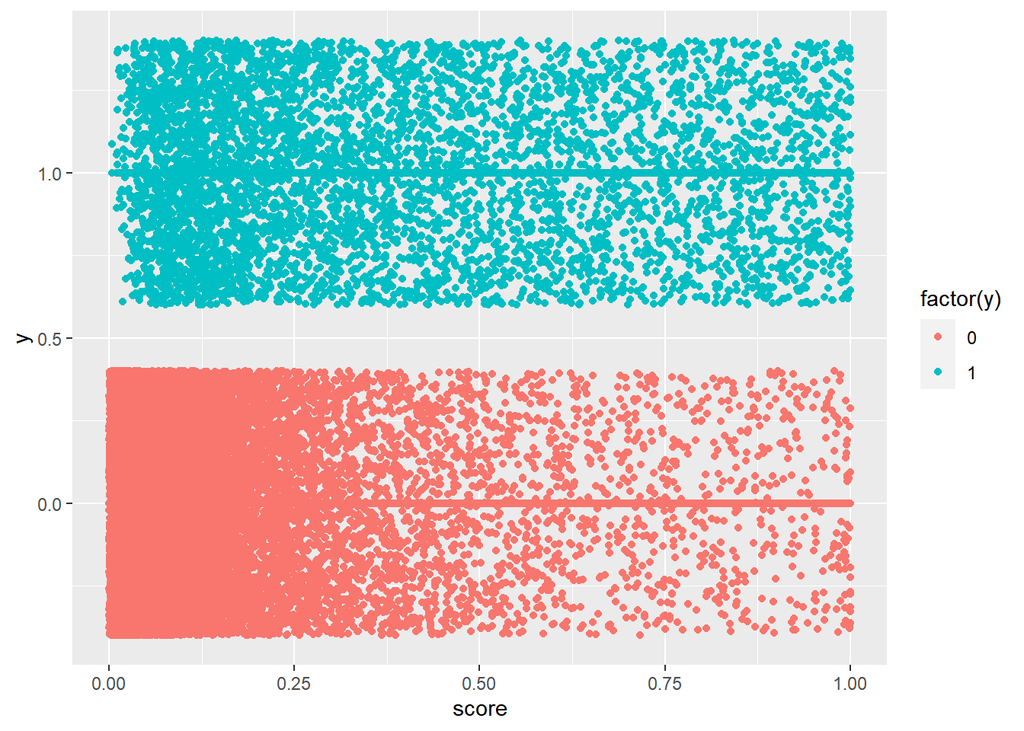

## Step 4. Finding Cutoff value and Perfomance measurements of the model.

```
## [1] 0.1010101
```

Therefore, 0.1010101 is the cutoff value by ks max method.

## Step 5.Predict if the client subscribe or no to term deposit

```
##
##   no  yes
## 3308 1213
```

Thus, 1213 customers out of 4521 subscribe to term deposit according to the model.

## Step 6: Creating confusion matrix to find the goodness of our model

```
## The sensitivity of the classification model is  97.66792 %
##
```

```
## The specificity of the classification model is  37.62215 %
##
```

```
## The Accuracy of the model is  0.8135893
##
```

```
## The Error of the model is  0.1864107 (according to ks method)
```

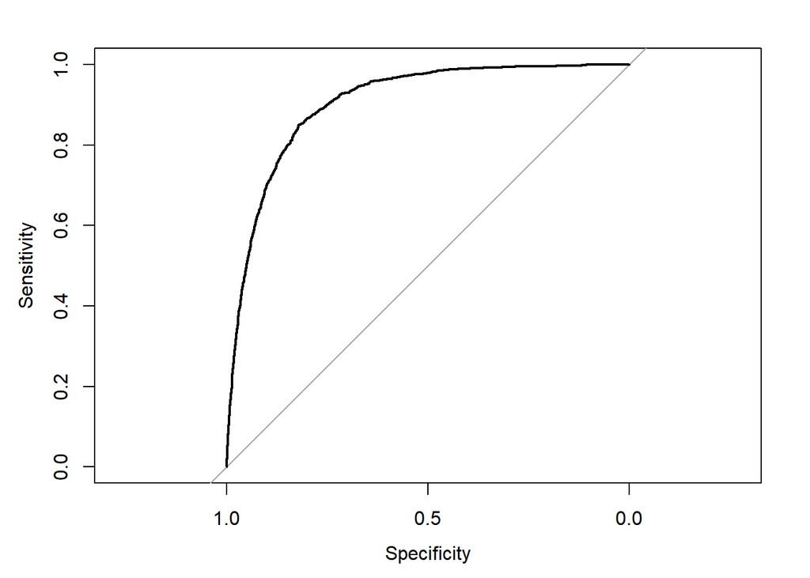

```
## Area under the curve: 0.9044
```